# GitHub Workshop 2022

2022-11-03

## What is Git?

[figure not shown]

## What is Git?

- Version control system
- Automatic
- History is immutable
- All changes are attributable
- Easy comparisons (“diffing”)
- Roll back one, some, or all changes

## Git in the EDL

- All scripts stored in GitHub
- All script work will follow a Git-based workflow

## Why Git?

- Redunancy and data loss prevention.
- Data and code are subject to different considerations.
- Easier collaboration, support, and accountability.
- A central location for all code written by the lab.

## Key Concepts

- Repository (“repo”)
- Cloning
- Commit
- Push
- Fetch/Pull

## Repository

A collection of related files to be managed together.

- Each project may be it’s own repository.
- Canonical version of the repo lives in GitHub.
- You do your work on a local copy of the repo.

## Cloning

Creates a local copy of a repo stored in GitHub.

- Typically only necessary once.

## Commit

Creates a snapshot of all files in the repo.

- Each commit is like an entry in an historical timeline of changes you’ve made.
- Commits are made to your local copy of the repository.
- Commit any time you do “meaningful” work.

## Push

Pushes changes to the remote repo and merges your changes with those made by your collaborators.

- Do this when you are finished working for the moment.
- Your entire commit history is also pushed.
- Ensures your collaborators see your changes and history.
- Backs up your work remotely.

## Fetch/Pull

Retrieves the latest changes from the remote repo and merges them with your local copy.

- You get all changes and history others have committed and pushed.
- Their changes and history merged with yours.
- (Github app says “Fetch” and may automatically pull, or may suggest you pull.)
- (Behind the scenes, Pull performs a Fetch command, then a Merge command.)

## Getting a repo on your computer

To work on a repository, you must **Clone** the repository.

This creates a local copy of the repository. Typically you only need to clone once.

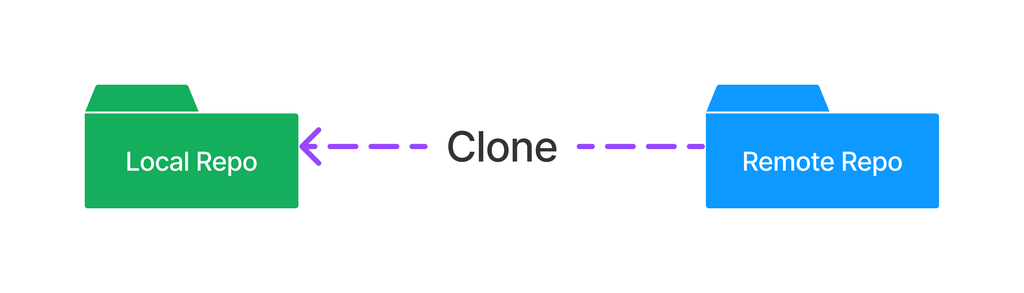

## Daily workflow

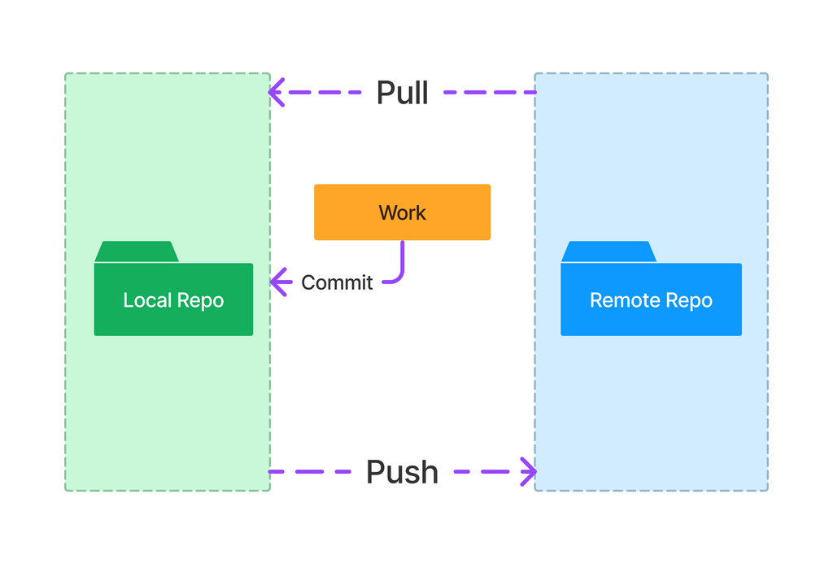

## When to fetch/pull, commit, and push?

- Pull when you start working.
- Commit regularly.
  - Any time you have something you can describe
    - E.g., “added placeholder function”
    - E.g., “preliminary attempt at variable transformation function”
- Push when done working for the time being.

## Let’s give it a try, part 1

- Clone the repo.
- Create a new R Markdown file.
- Write your name and a TV show you’d recommend to a friend.
- Save the file in /tv-project with your first name as the filename (e.g., `scott.Rmd`).
- Commit, make sure to add a description like “Added recommendation”
- Push to remote.

## Let’s give it a try, part 2

- Pull.
- Add a line describing what you like about your show.
- Commit, make sure to add a description like “added why I like it”.
- Push to remote.

## Branching

Branches create a separate path for you to do new work.

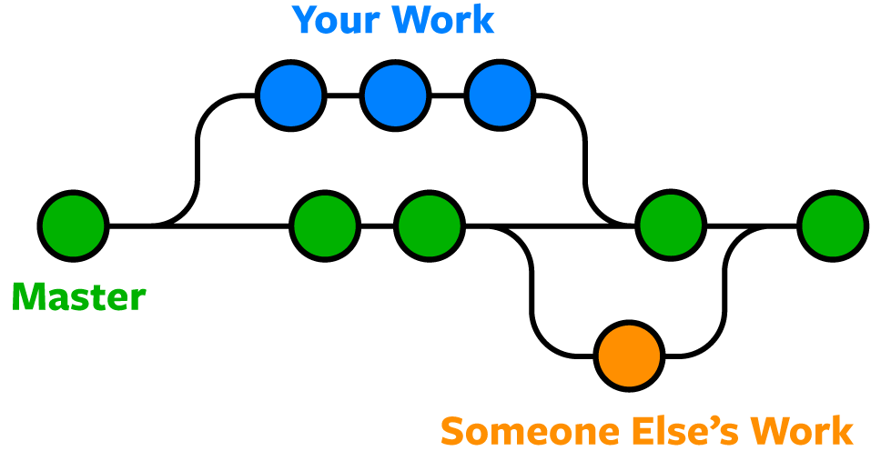

## Branching

- Every repo has a `main` branch.
- Additional branches created as needed.
- Work done on one branch has NO IMPACT on other branches.
- Branches are “merged” into `main` with a Pull Request.

## Branching

- Create new branch `scott/new-data-cleaning`.
- Do your work.
- Did it work out? **Merge!**
- Didn’t go as planned? **Delete the branch!**

## Let’s make a branch!

- In GitHub Desktop create a new branch `name/rec-review`.
- Make sure you’re on your new branch!
- Publish the branch.
- Open the `.Rmd` of the person whose name is next in the alphabet to your own.
- Write “I have seen it!” or “I haven’t seen it!” below their recommendation.
- In GitHub Desktop: commit (don’t forget a description!) and push.
- (try switching between branches right now and see how the `.Rmd` file changes!)

## Let’s make a PR and merge!

- On GitHub.com or in GitHub Desktop, create a Pull Request
- Review changes to ensure you’re merging in what you want.
- You may have to get approval to merge your changes.
- Approvers and others can comment on specific lines of code.
- Merge!